# Avaliações no IMDb: fatores e enviesamentos

Seminário de Sistemas e Aplicações — MEI, UFP

Frederico Soliz · 2022125511@ufp.edu.pt

27 de outubro de 2026

## Porquê este tema e o que quero saber

**Porquê este tema**

- **Uso pessoal.** Escolho filmes pela nota do IMDb, mas depois de os ver a minha opinião fica muitas vezes longe dela. O que é que a nota mede?
- **Impacto real.** A nota ordena rankings (*Top 250*) e recomendações. Os enviesamentos passam para quem a usa.
- **Ciência de dados.** Dados públicos, grandes (1,7 M títulos com nota) e sujos: o ciclo completo, da limpeza à modelação.

**Pergunta de partida:** a nota do IMDb mede a qualidade, ou depende do **género**, da **duração**, da **época**, da **popularidade** e do **realizador**?

**O que me levou a desconfiar**

- **Géneros:** um 7 vale o mesmo no terror (média 4,7) e no documentário (média 7,0)?
- **Época:** a média cai de 6,5 (anos 20) para 5,8 (anos 2020). O cinema piorou, ou só os bons clássicos são lembrados?
- **Popularidade:** os mais votados têm melhor nota. Qualidade ou tipo de público?

## Os dados: IMDb Non-Commercial Datasets

- 4 ficheiros TSV públicos, juntos por `tconst` / `nconst`
  - `title.basics` · `title.ratings` · `title.crew` · `name.basics`
- Descarregados **pelo próprio código**, com *snapshot* de 26/10/2026
- Licença não comercial → no Git fica o código, não os dados

12 898 691

títulos no ficheiro original

142 734

longas-metragens após limpeza

## Preparação: cada corte tem uma razão

| Problema | Decisão | Porquê | Filmes restantes |
| --- | --- | --- | --- |
| 12,9 M títulos de todos os tipos | só `movie` | episódios, curtas e vídeos têm outros votantes | 760 577 |
| Conteúdo adulto | excluir | população e lógica de votação diferentes | 751 475 |
| Filmes sem nota | *join* com `title.ratings` | sem variável resposta | 346 012 |
| Antes de 1920 e ano de 2026 | **1920–2025** | poucos votos / votos ainda a acumular | 337 312 |
| Médias de 3 ou 10 votos | **≥ 100 votos** | erro-padrão da média ≈ 0,2 pontos | 144 772 |
| `\N` na duração ou géneros | remover | após o filtro de votos só falta ≈ 1 % | 142 832 |
| Durações de 1 a 51 420 min | **40–300 min** | definição de longa-metragem (AMPAS/BFI) | 142 734 |

**Transformações:** `"Comedy,Drama,Romance"` → **21 variáveis 0/1** (a ordem é alfabética, não há género principal) · votos → **`log10(votos)`** (assimetria 18,8 → quase simétrica) · realizador via `title.crew` + `name.basics` · década e idade derivadas do ano

## Cinco perguntas

1. **Fatores:** que fatores explicam a nota, e com que peso? *(regressão linear múltipla)*
2. **Sobrevivência:** os filmes antigos são melhores ou é viés de sobrevivência? *(3 especificações)*
3. **Popularidade × género:** a relação votos–nota é igual em todos os géneros? *(interação + teste F)*
4. **Realizador:** quanto da nota se deve a quem realizou? *(modelo misto, ICC)*
5. **Previsão:** dá para prever se um filme terá nota ≥ 7? *(logística vs. random forest)*

## O género separa muito as notas

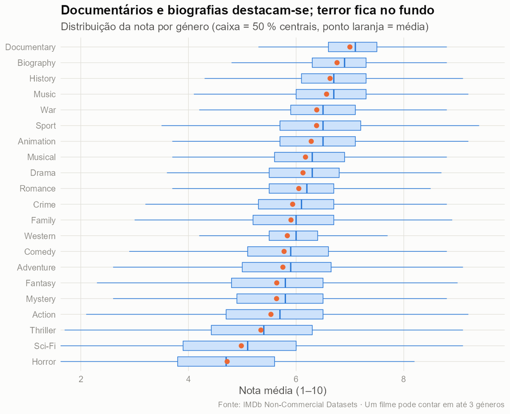

## Uma pista: o topo não mudou em 100 anos

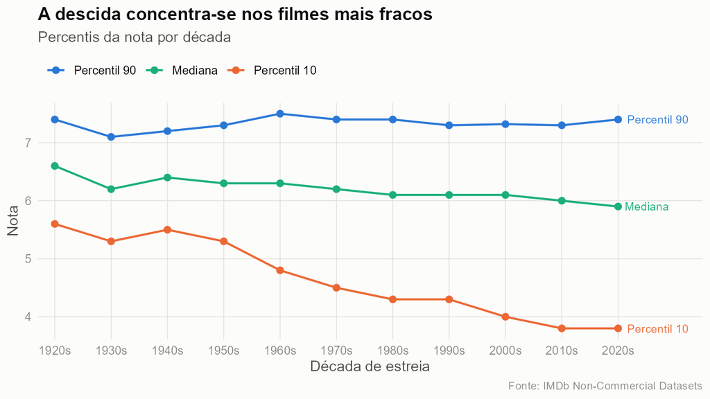

Os melhores filmes de cada época têm a mesma nota (P90 ≈ 7,3). O que cai é a **cauda de baixo**.

## P1 · O género é o fator dominante

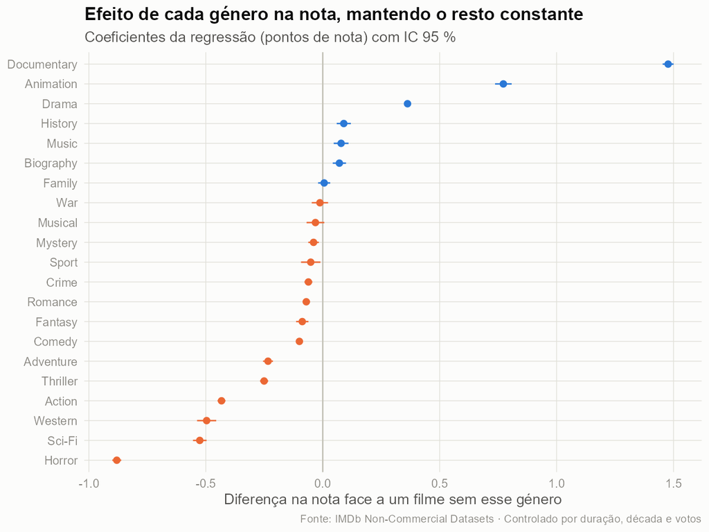

**R² = 0,38**

Perda de R² sem cada bloco:

| Bloco | ΔR² |
| --- | --- |
| Géneros | 25,0 p.p. |
| Popularidade (votos) | 5,9 p.p. |
| Década | 4,0 p.p. |
| Duração | 3,5 p.p. |

62 % **fica por explicar**, e aí cabe a “qualidade” que os dados não medem.

## P2 · Os clássicos eram melhores?

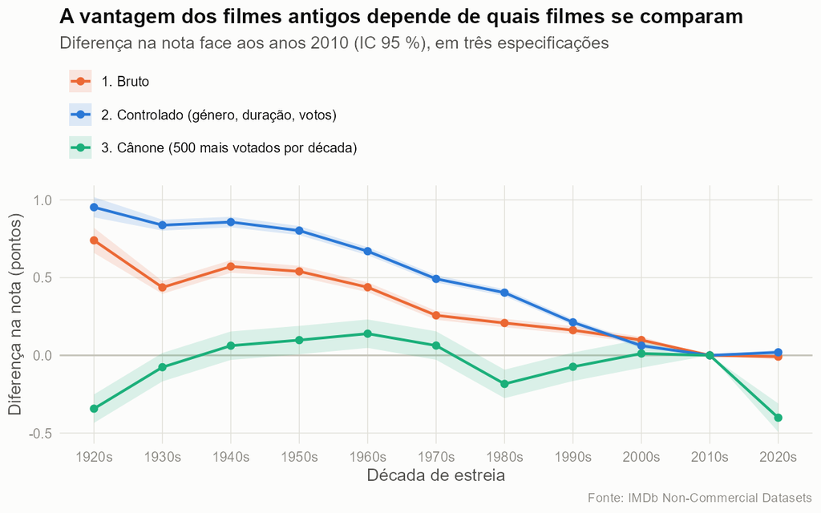

Entre os **500 mais votados de cada década**, a vantagem dos antigos **desaparece** → **viés de sobrevivência**.

## P3 · A popularidade “vale” mais nuns géneros

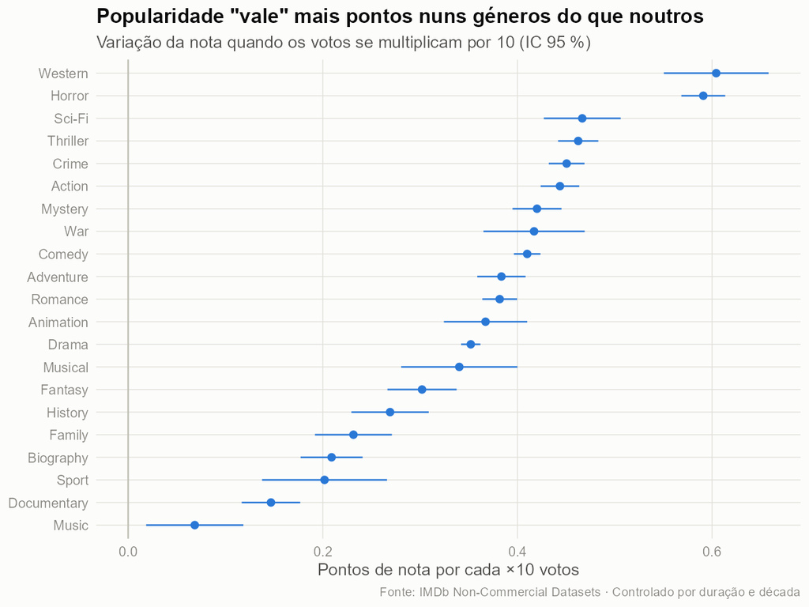

Interação votos × género: **F = 68,7, p < 0,001**

- **Western, terror, ficção científica:** muitos filmes baratos e mal avaliados; os que chegam ao grande público são os bons.
- **Música, documentário:** um público de nicho e interessado dá notas altas mesmo com poucos votos.

## P4 · O realizador pesa mais do que tudo o resto

50 %

da variância da nota está **entre realizadores**, mesmo depois de controlar género, duração, década e votos (ICC)

90 171 filmes · 13 253 realizadores (≥ 3 filmes)

| Realizador | Filmes | Efeito (pontos) |
| --- | --- | --- |
| Shoojit Sircar | 8 | +0,72 |
| Asghar Farhadi | 9 | +0,60 |
| Tommy Wirkola | 8 | +0,53 |
| Mamoru Hosoda | 8 | +0,53 |
| Nuri Bilge Ceylan | 10 | +0,50 |
| Jackie Chan | 11 | +0,49 |
| Christopher Nolan | 12 | +0,47 |
| Sean Baker | 8 | +0,38 |

O topo absoluto é de realizadores de nicho com poucas centenas de votos, o que pode indicar votação organizada.

## P5 · Prever um filme “bom” (nota ≥ 7)

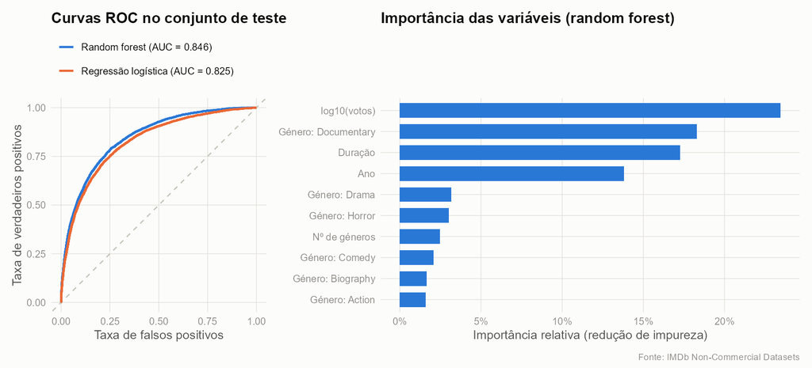

| Modelo | AUC | Accuracy | Sensibilidade |
| --- | --- | --- | --- |
| Referência (prever sempre “não”) | 0,500 | 0,798 | 0,00 |
| Regressão logística | 0,825 | 0,833 | 0,37 |
| Random forest | 0,846 | 0,841 | 0,42 |

## Conclusões

P1 O que explica a nota de um filme?

Sobretudo o género. O modelo explica 38 % das diferenças de nota, e cerca de dois terços disso vêm do género. Com tudo o resto igual, um documentário tem +1,5 pontos e um filme de terror −0,9. Duração, época e popularidade pesam pouco. Os outros 62 % ficam por explicar: é aí que entra a qualidade do argumento, da realização e dos atores, que estes dados não medem.

P2 Os filmes antigos são mesmo melhores?

Não: é viés de sobrevivência. Em média, um filme dos anos 20 tem +0,7 pontos do que um dos anos 2010. Mas quando comparo só os 500 filmes mais votados de cada década (os que cada época deixou para a história), a vantagem desaparece (−0,3). Dos filmes antigos só continuam a ser vistos os bons; dos recentes, entram todos, bons e maus.

P3 Ser popular ajuda a nota da mesma forma em todos os géneros?

Não. Em todos os géneros, os filmes mais votados têm nota mais alta, mas esse efeito é até 9 vezes maior no western e no terror do que na música e nos documentários. No terror, os filmes pouco vistos costumam ser fracos. Nos documentários, até os pouco vistos têm boas notas, porque quem os vê já gosta do tema.

P4 O realizador importa?

Muito: é o fator mais forte. Cerca de 50 % das diferenças de nota entre filmes devem-se a quem os realizou, mesmo depois de descontar género, duração, época e popularidade. Saber quem realizou um filme diz mais sobre a nota do que todas as outras variáveis juntas.

P5 Consigo prever se um filme vai ter nota ≥ 7?

Em parte. Perante um filme bom e um fraco, o modelo dá maior probabilidade ao bom em 85 % das vezes (AUC = 0,85). Mas com o corte habitual de 50 % só identifica 42 % dos filmes bons. Serve para ordenar e filtrar sugestões, não para decidir sozinho.

**Mensagem final:** a nota do IMDb é útil, mas **não é comparável entre géneros nem entre épocas**. Um 7 num filme de terror é mais raro do que um 7 num documentário, e um clássico com 7,5 não é melhor do que um filme atual com a mesma nota.

## Limitações

- **Quem vota no IMDb ≠ público em geral:** a amostra é autosselecionada e a nota mede o entusiasmo de quem decide votar.
- **Possível manipulação de votos:** realizadores de nicho com notas perto de 9 e poucas centenas de votos.
- **Associação, não causalidade:** nenhum modelo diz que alongar um filme *causa* melhor nota.
- **Snapshot de uma data:** os filmes dos anos 2020 ainda estão a acumular votos.
- **Escolhas de limpeza:** o limiar de 100 votos e o intervalo de 40–300 min são decisões justificadas, mas não únicas.
- **Crítica vs. público:** o IMDb não publica notas da crítica, por isso esta comparação ficou de fora.

## Obrigado

**Repositório:** https://github.com/FredericoSoliz/ssa-imdb

R · Quarto · data.table · dplyr · ggplot2 · lme4 · ranger · pROC